# Analyzing WeRateDogs' Twitter Account

Everyone loves dogs, that's why WeRateDogs was made, to rate the cutest little dogs in existense.

We analyzed their Twitter data and here's what we found out.

We analyzed all dog images with a neural network and got the amount of likes and retweets for each post.

This is the dog that Twitter users like most:

[figure not shown]

I honestly can't disagree with them on that one.. This is the labrador retriever, the second guess of our neural network.

Let's see the highest rated dog..

Here's the highest rated dog from WeRateDogs:

[figure not shown]

This one definetly deserves the high rating! Our neural network guessed pomeranian and that was correct!

You might be thinking about how WeRateDogs operates, we analyzed that aswell.

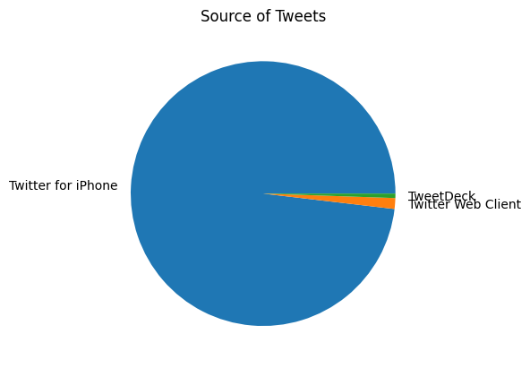

WeRateDogs seems to operate mostly on their iPhone, which I didn't expect for such a big popular account honestly.

```
timestamp
0     222
1     236
2     170
3     134
4      75
5      18
6       3
13      1
14      4
15     76
16    166
17    142
18     81
19     68
20     62
21     57
22     55
23     96
Name: count, dtype: int64
```

The exact time zone of the WeRateDogs account is unclear, but it's probably in the west. The timestamp data is in UTC+00 which is Greenwich Mean Time.

WeRateDogs was started by Matt in 2015 and has been rating dogs ever since, we have read the insights and visualizations that resulted from analyzing the Twitter posts over ~3 years.